# Articulatory Analysis

Tabea Thies

2022-09-13

# Analysis of tongue body movements comparing healthy controls and speakers with PD

Load necessary packages

```r
library(tidyverse)
library(ggplot2)
library(lme4)
library(lmerTest)
library(merTools)
library(sjPlot)
library(sjmisc)
```

Load data set

```r
data <- read_csv('../data/articulation.csv')
```

Create subset for the comparison Controls vs PD (in med-OFF)

```r
data_red <-  filter(data, med_con %in% c('Control', 'med-OFF'))
```

# Movement duration

Descriptive stats for reporting values in Section 6.2.3

```r
DUR_stats <- data_red %>%
  group_by(med_con) %>%
  summarise(M = round(mean(GAI_V1)),
            SD = round(sd(GAI_V1)))
DUR_stats
```

```
## # A tibble: 2 x 3
##   med_con     M    SD
##   <chr>   <dbl> <dbl>
## 1 Control   170    36
## 2 med-OFF   194    46
```

```r
DUR_stats2 <- data_red %>%
  group_by(med_con, focus_con) %>%
  summarise(M = round(mean(GAI_V1)),
            SD = round(sd(GAI_V1)))
DUR_stats2
```

```
## # A tibble: 6 x 4
## # Groups:   med_con [2]
##   med_con focus_con       M    SD
##   <chr>   <chr>       <dbl> <dbl>
## 1 Control background    160    31
## 2 Control broad         174    40
## 3 Control contrastive   177    35
## 4 med-OFF background    186    43
## 5 med-OFF broad         193    45
## 6 med-OFF contrastive   203    49
```

Plot tongue body movement duration

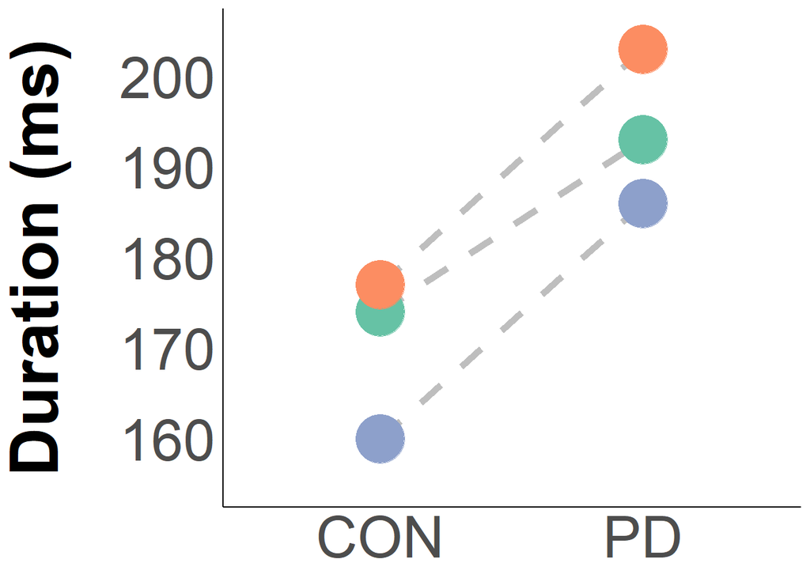

```r
DUR_stats2 %>%
  ggplot(aes(x=med_con, y=M, group = focus_con)) +
  geom_line(linetype="dashed", color="gray", size=2)+
  geom_point(size = 14, aes(color = focus_con))+
  theme_classic() +
  theme(legend.position = 'none')+
  theme(legend.title = element_blank(),
        legend.text = element_text(size = 36))+
  scale_color_manual(values = c("#8da0cb", "#66c2a5", "#fc8d62")) +
  xlab(NULL) +
  scale_x_discrete(labels = c('CON','PD'))+
  coord_cartesian(ylim = c(155, 205)) +
  scale_y_continuous(breaks = seq(160, 200, 10)) +
  ylab("Duration (ms)")+
  theme(axis.title.y = element_text(face = 'bold', size = 42, margin = margin(r = 30)))+
  theme(strip.text.x = element_text(size=38, face="bold"),
        strip.background = element_blank())+
  theme(axis.text.x = element_text(size = 36),
        axis.text.y = element_text(size = 36)) +
  theme(axis.ticks.x = element_blank(),
        axis.ticks.y = element_blank())
```

Create linear mixed model to investigate disease effect on TB duration

```r
mdl <- lmer(GAI_V1 ~ med_con + focus_con + vowel + cons + age  + (1 + focus_con|speaker), data_red, REML = FALSE)
```

Look at model summary

```r
summary(mdl)
```

```
## Linear mixed model fit by maximum likelihood . t-tests use Satterthwaite's
##   method [lmerModLmerTest]
## Formula: GAI_V1 ~ med_con + focus_con + vowel + cons + age + (1 + focus_con |
##     speaker)
##    Data: data_red
##
##      AIC      BIC   logLik deviance df.resid
##   7696.8   7776.1  -3831.4   7662.8      767
##
## Scaled residuals:
##     Min      1Q  Median      3Q     Max
## -3.7832 -0.6417 -0.0674  0.6051  3.5135
##
## Random effects:
##  Groups   Name                 Variance Std.Dev. Corr
##  speaker  (Intercept)          438.55   20.942
##           focus_conbroad        29.98    5.476   0.50
##           focus_concontrastive  19.95    4.466   0.94 0.77
##  Residual                      930.02   30.496
## Number of obs: 784, groups:  speaker, 26
##
## Fixed effects:
##                      Estimate Std. Error       df t value Pr(>|t|)
## (Intercept)          133.0032    34.3525  26.8636   3.872 0.000625 ***
## med_conmed-OFF        25.3493     8.9772  26.4406   2.824 0.008908 **
## focus_conbroad        10.6392     2.8741  27.8752   3.702 0.000934 ***
## focus_concontrastive  17.0883     2.8080 105.0306   6.086 1.92e-08 ***
## vowele               -24.3841     3.4378 732.5133  -7.093 3.10e-12 ***
## voweli               -21.7875     3.4650 732.4096  -6.288 5.53e-10 ***
## vowelo               -15.2287     3.4541 732.8652  -4.409 1.19e-05 ***
## vowelu               -27.7630     3.4535 731.8666  -8.039 3.63e-15 ***
## conslab               -7.4937     2.1790 732.5808  -3.439 0.000617 ***
## age                    0.8309     0.5700  26.6018   1.458 0.156652
## ---
## Signif. codes:  0 '***' 0.001 '**' 0.01 '*' 0.05 '.' 0.1 ' ' 1
##
## Correlation of Fixed Effects:
##             (Intr) m_-OFF fcs_cnb fcs_cnc vowele voweli vowelo vowelu conslb
## md_cnmd-OFF -0.139
## focus_cnbrd -0.012  0.001
## fcs_cncntrs -0.001  0.001  0.529
## vowele      -0.051 -0.004  0.002   0.007
## voweli      -0.047  0.000  0.000   0.000   0.504
## vowelo      -0.048 -0.001  0.009   0.007   0.505  0.501
## vowelu      -0.049 -0.003  0.004   0.005   0.505  0.502  0.503
## conslab     -0.036 -0.003  0.008   0.007   0.002 -0.008 -0.008 -0.004
## age         -0.980  0.009 -0.002  -0.001   0.000 -0.004 -0.003 -0.001  0.005
## optimizer (nloptwrap) convergence code: 0 (OK)
## boundary (singular) fit: see help('isSingular')
```

extracting fit statistics for reporting in text

```r
tab_model(mdl)
```

|  | GAI V 1 |  |  |
| --- | --- | --- | --- |
| Predictors | Estimates | CI | p |
| (Intercept) | 133.00 | 65.57 – 200.44 | **<0.001** |
| med con [med-OFF] | 25.35 | 7.73 – 42.97 | **0.005** |
| focus con [broad] | 10.64 | 5.00 – 16.28 | **<0.001** |
| focus con [contrastive] | 17.09 | 11.58 – 22.60 | **<0.001** |
| vowel [e] | -24.38 | -31.13 – -17.64 | **<0.001** |
| vowel [i] | -21.79 | -28.59 – -14.99 | **<0.001** |
| vowel [o] | -15.23 | -22.01 – -8.45 | **<0.001** |
| vowel [u] | -27.76 | -34.54 – -20.98 | **<0.001** |
| cons [lab] | -7.49 | -11.77 – -3.22 | **0.001** |
| age | 0.83 | -0.29 – 1.95 | 0.145 |
| Random Effects |  |  |  |
| σ<sup>2</sup> | 930.02 |  |  |
| τ<sub>00</sub> <sub>speaker</sub> | 438.55 |  |  |
| τ<sub>11</sub> <sub>speaker.focus_conbroad</sub> | 29.98 |  |  |
| τ<sub>11</sub> <sub>speaker.focus_concontrastive</sub> | 19.95 |  |  |
| ρ<sub>01</sub> | 0.50 |  |  |
|  | 0.94 |  |  |
| ICC | 0.37 |  |  |
| N <sub>speaker</sub> | 26 |  |  |
| Observations | 784 |  |  |
| Marginal R<sup>2</sup> / Conditional R<sup>2</sup> | 0.196 / 0.495 |  |  |

# Movement amplitude

Descriptive stats for reporting values in Section 6.2.3

```r
DISPL_stats <- data_red %>%
  group_by(med_con) %>%
  summarise(M = round(mean(disp_V1_abs),1),
            SD = round(sd(disp_V1_abs),1))
DISPL_stats
```

```
## # A tibble: 2 x 3
##   med_con     M    SD
##   <chr>   <dbl> <dbl>
## 1 Control   7.3   4.2
## 2 med-OFF   7.8   4.5
```

```r
DISPL_stats2 <- data_red %>%
  group_by(med_con, focus_con) %>%
  summarise(M = round(mean(disp_V1_abs),1),
            SD = round(sd(disp_V1_abs),1))
DISPL_stats2
```

```
## # A tibble: 6 x 4
## # Groups:   med_con [2]
##   med_con focus_con       M    SD
##   <chr>   <chr>       <dbl> <dbl>
## 1 Control background    6.7   3.9
## 2 Control broad         7.4   4.4
## 3 Control contrastive   7.7   4.2
## 4 med-OFF background    7.4   4.2
## 5 med-OFF broad         7.9   4.5
## 6 med-OFF contrastive   8     4.8
```

Plot tongue body movement amplitude

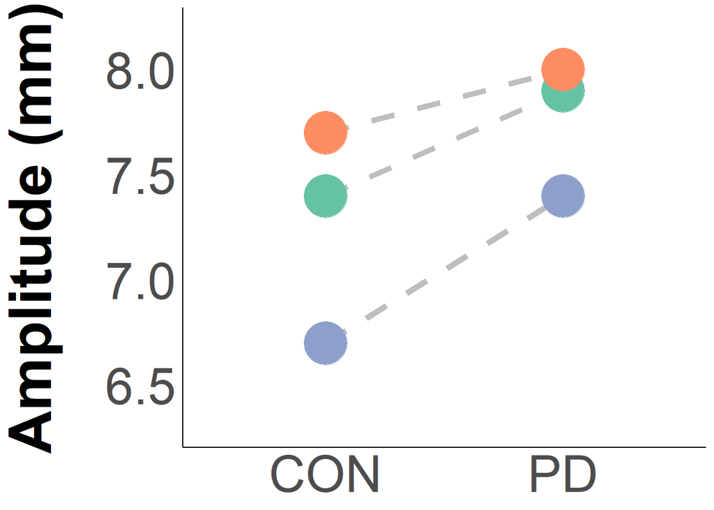

```r
DISPL_stats2 %>%
  ggplot(aes(x=med_con, y=M, group = focus_con)) +
  geom_line(linetype="dashed", color="gray", size=2)+
  geom_point(size = 14, aes(color = focus_con))+
  theme_classic() +
  theme(legend.position = 'none')+
  theme(legend.title = element_blank(),
        legend.text = element_text(size = 36))+
  scale_color_manual(values = c("#8da0cb", "#66c2a5", "#fc8d62")) +
  coord_cartesian(ylim = c(6.3, 8.2)) +
  scale_y_continuous(breaks = seq(6.5, 8, 0.5)) +
  xlab(NULL) +
  scale_x_discrete(labels = c('CON','PD'))+
  ylab("Amplitude (mm)")+
  theme(axis.title.y = element_text(face = 'bold', size = 42, margin = margin(r = 30)))+
  theme(strip.text.x = element_text(size=38, face="bold"),
        strip.background = element_blank())+
  theme(axis.text.x = element_text(size = 36),
        axis.text.y = element_text(size = 36)) +
  theme(axis.ticks.x = element_blank(),
        axis.ticks.y = element_blank())
```

Create linear mixed model to investigate disease effect on TB amplitude

```r
mdl2 <- lmer(disp_V1_abs ~ med_con + focus_con + vowel + cons + age  + (1 + focus_con|speaker), data_red, REML = FALSE)
```

Look at model summary

```r
summary(mdl2)
```

```
## Linear mixed model fit by maximum likelihood . t-tests use Satterthwaite's
##   method [lmerModLmerTest]
## Formula: disp_V1_abs ~ med_con + focus_con + vowel + cons + age + (1 +
##     focus_con | speaker)
##    Data: data_red
##
##      AIC      BIC   logLik deviance df.resid
##   3777.3   3856.6  -1871.7   3743.3      767
##
## Scaled residuals:
##     Min      1Q  Median      3Q     Max
## -4.1513 -0.6169 -0.0014  0.6200  3.6065
##
## Random effects:
##  Groups   Name                 Variance Std.Dev. Corr
##  speaker  (Intercept)          3.19016  1.7861
##           focus_conbroad       0.01940  0.1393   1.00
##           focus_concontrastive 0.02232  0.1494   1.00 1.00
##  Residual                      6.30255  2.5105
## Number of obs: 784, groups:  speaker, 26
##
## Fixed effects:
##                       Estimate Std. Error        df t value Pr(>|t|)
## (Intercept)           11.15429    2.87502  26.38561   3.880 0.000627 ***
## med_conmed-OFF         0.63674    0.75185  26.02042   0.847 0.404776
## focus_conbroad         0.55543    0.22116 403.60993   2.511 0.012413 *
## focus_concontrastive   0.71026    0.22157 372.86077   3.206 0.001464 **
## vowele                -7.39708    0.28300 757.97890 -26.138  < 2e-16 ***
## voweli                -5.88180    0.28524 757.97529 -20.621  < 2e-16 ***
## vowelo                -5.51786    0.28434 757.97576 -19.406  < 2e-16 ***
## vowelu                -8.81583    0.28429 757.96062 -31.010  < 2e-16 ***
## conslab                0.28162    0.17937 757.96886   1.570 0.116819
## age                    0.01761    0.04769  26.10247   0.369 0.714995
## ---
## Signif. codes:  0 '***' 0.001 '**' 0.01 '*' 0.05 '.' 0.1 ' ' 1
##
## Correlation of Fixed Effects:
##             (Intr) m_-OFF fcs_cnb fcs_cnc vowele voweli vowelo vowelu conslb
## md_cnmd-OFF -0.140
## focus_cnbrd -0.022  0.001
## fcs_cncntrs -0.021  0.001  0.506
## vowele      -0.050 -0.003  0.003   0.007
## voweli      -0.047  0.000  0.000   0.000   0.504
## vowelo      -0.048 -0.001  0.010   0.007   0.505  0.502
## vowelu      -0.049 -0.002  0.005   0.005   0.505  0.502  0.503
## conslab     -0.034 -0.002  0.009   0.008   0.002 -0.008 -0.008 -0.004
## age         -0.980  0.009 -0.002  -0.001   0.000 -0.003 -0.002 -0.001  0.003
## optimizer (nloptwrap) convergence code: 0 (OK)
## boundary (singular) fit: see help('isSingular')
```

extracting fit statistics for reporting in text

```r
tab_model(mdl2)
```

|  | disp V 1 abs |  |  |
| --- | --- | --- | --- |
| Predictors | Estimates | CI | p |
| (Intercept) | 11.15 | 5.51 – 16.80 | **<0.001** |
| med con [med-OFF] | 0.64 | -0.84 – 2.11 | 0.397 |
| focus con [broad] | 0.56 | 0.12 – 0.99 | **0.012** |
| focus con [contrastive] | 0.71 | 0.28 – 1.15 | **0.001** |
| vowel [e] | -7.40 | -7.95 – -6.84 | **<0.001** |
| vowel [i] | -5.88 | -6.44 – -5.32 | **<0.001** |
| vowel [o] | -5.52 | -6.08 – -4.96 | **<0.001** |
| vowel [u] | -8.82 | -9.37 – -8.26 | **<0.001** |
| cons [lab] | 0.28 | -0.07 – 0.63 | 0.117 |
| age | 0.02 | -0.08 – 0.11 | 0.712 |
| Random Effects |  |  |  |
| σ<sup>2</sup> | 6.30 |  |  |
| τ<sub>00</sub> <sub>speaker</sub> | 3.19 |  |  |
| τ<sub>11</sub> <sub>speaker.focus_conbroad</sub> | 0.02 |  |  |
| τ<sub>11</sub> <sub>speaker.focus_concontrastive</sub> | 0.02 |  |  |
| ρ<sub>01</sub> | 1.00 |  |  |
|  | 1.00 |  |  |
| N <sub>speaker</sub> | 26 |  |  |
| Observations | 784 |  |  |
| Marginal R<sup>2</sup> / Conditional R<sup>2</sup> | 0.593 / NA |  |  |

## Explore random effects with function REsim

Effects for individual levels are simulated  
Output: mean, median and sd of the random effect estimates

Plots estimated random effects for each participant  
95 % Intervals that do not overlap zero are bold

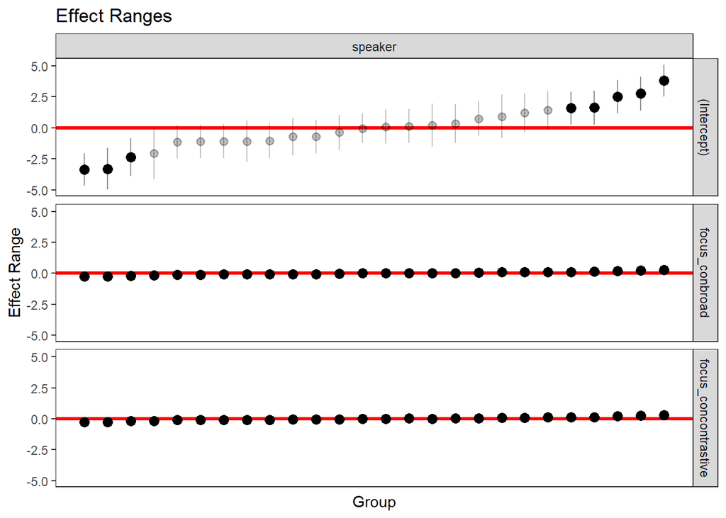

```r
randoms <- REsim(mdl2)
plotREsim(randoms)
```

Plot estimated 95 % interval spans for the intercept of TB amplitude

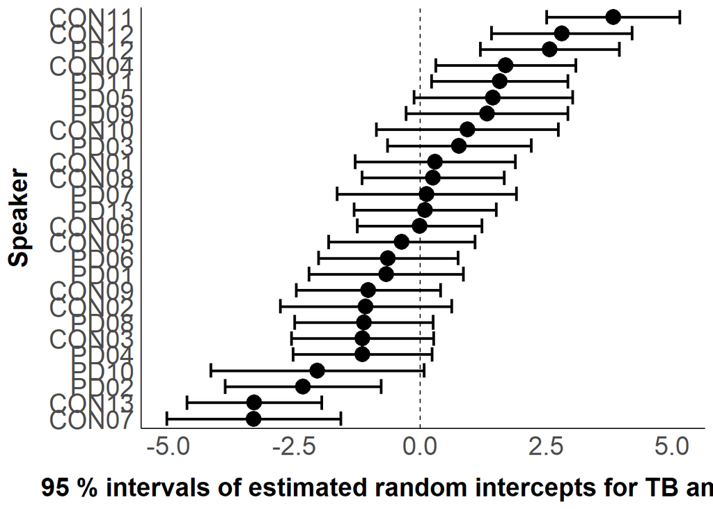

```r
random2 <- subset(randoms, term == "(Intercept)")

random2 %>%
  ggplot(aes(x = mean, xmin = mean-sd-sd, xmax = mean+sd+sd, y = reorder(groupID, mean))) +
  geom_vline(xintercept = 0, linetype = 'dashed') +
  geom_point(size = 5)+
  geom_errorbar(size = 1) +
  theme_classic()+
  xlab('95 % intervals of estimated random intercepts for TB amplitude') +
  ylab('Speaker')+
  theme(axis.title.y = element_text(face = 'bold', size = 18, margin = margin(r = 12)))+
  theme(axis.title.x = element_text(face = 'bold', size = 18, margin = margin(t = 12)))+
  theme(strip.text.x = element_text(size=18, face="bold"),
        strip.background = element_blank())+
  theme(axis.text.x = element_text(size = 18),
        axis.text.y = element_text(size = 18)) +
  theme(axis.ticks.x = element_blank(),
        axis.ticks.y = element_blank())+
  theme(legend.position = "top",
        legend.title = element_blank(),
        legend.text = element_text(size = 18))
```

# Movement peak velocities

Descriptive stats for reporting values in Section 6.2.3

```r
PVEL_stats <- data_red %>%
  group_by(med_con) %>%
  summarise(M = round(mean(pvel_V1_abs)),
            SD = round(sd(pvel_V1_abs)))
PVEL_stats
```

```
## # A tibble: 2 x 3
##   med_con     M    SD
##   <chr>   <dbl> <dbl>
## 1 Control    76    37
## 2 med-OFF    74    41
```

```r
PVEL_stats2 <- data_red %>%
  group_by(med_con, focus_con) %>%
  summarise(M = round(mean(pvel_V1_abs)),
            SD = round(sd(pvel_V1_abs)))
PVEL_stats2
```

```
## # A tibble: 6 x 4
## # Groups:   med_con [2]
##   med_con focus_con       M    SD
##   <chr>   <chr>       <dbl> <dbl>
## 1 Control background     74    36
## 2 Control broad          75    37
## 3 Control contrastive    78    39
## 4 med-OFF background     72    41
## 5 med-OFF broad          76    39
## 6 med-OFF contrastive    75    42
```

Create linear mixed model to investigate disease effect on TB velocity

```r
mdl3 <- lmer(pvel_V1_abs ~ med_con + focus_con + vowel + cons + age  + (1 + focus_con|speaker), data_red, REML = FALSE)
```

Look at model summary

```r
summary(mdl3)
```

```
## Linear mixed model fit by maximum likelihood . t-tests use Satterthwaite's
##   method [lmerModLmerTest]
## Formula: pvel_V1_abs ~ med_con + focus_con + vowel + cons + age + (1 +
##     focus_con | speaker)
##    Data: data_red
##
##      AIC      BIC   logLik deviance df.resid
##   7326.9   7406.2  -3646.4   7292.9      767
##
## Scaled residuals:
##     Min      1Q  Median      3Q     Max
## -3.2627 -0.6587 -0.0370  0.6839  3.1422
##
## Random effects:
##  Groups   Name                 Variance Std.Dev. Corr
##  speaker  (Intercept)          316.995  17.804
##           focus_conbroad         1.067   1.033   -1.00
##           focus_concontrastive   8.101   2.846    1.00 -1.00
##  Residual                      582.426  24.134
## Number of obs: 784, groups:  speaker, 26
##
## Fixed effects:
##                       Estimate Std. Error        df t value Pr(>|t|)
## (Intercept)          108.59465   26.71776  26.88136   4.065 0.000376 ***
## med_conmed-OFF         1.27665    6.98119  26.43880   0.183 0.856295
## focus_conbroad         1.98296    2.11939 493.12023   0.936 0.349923
## focus_concontrastive   3.00293    2.18382 158.20715   1.375 0.171050
## vowele               -62.86404    2.72045 757.76811 -23.108  < 2e-16 ***
## voweli               -43.94323    2.74199 757.77100 -16.026  < 2e-16 ***
## vowelo               -42.39508    2.73336 757.77226 -15.510  < 2e-16 ***
## vowelu               -68.15866    2.73294 757.75519 -24.940  < 2e-16 ***
## conslab                8.30286    1.72431 757.75966   4.815 1.78e-06 ***
## age                    0.05981    0.44262  26.47289   0.135 0.893529
## ---
## Signif. codes:  0 '***' 0.001 '**' 0.01 '*' 0.05 '.' 0.1 ' ' 1
##
## Correlation of Fixed Effects:
##             (Intr) m_-OFF fcs_cnb fcs_cnc vowele voweli vowelo vowelu conslb
## md_cnmd-OFF -0.140
## focus_cnbrd -0.049  0.001
## fcs_cncntrs -0.004  0.000  0.455
## vowele      -0.051 -0.002  0.003   0.007
## voweli      -0.047  0.000  0.000   0.000   0.504
## vowelo      -0.050  0.000  0.010   0.007   0.505  0.502
## vowelu      -0.051 -0.002  0.005   0.005   0.505  0.502  0.503
## conslab     -0.035 -0.002  0.009   0.007   0.002 -0.008 -0.008 -0.004
## age         -0.978  0.009 -0.003  -0.001   0.000 -0.004 -0.002 -0.001  0.002
## optimizer (nloptwrap) convergence code: 0 (OK)
## boundary (singular) fit: see help('isSingular')
```

extracting fit statistics for reporting in text

```r
tab_model(mdl3)
```

|  | pvel V 1 abs |  |  |
| --- | --- | --- | --- |
| Predictors | Estimates | CI | p |
| (Intercept) | 108.59 | 56.15 – 161.04 | **<0.001** |
| med con [med-OFF] | 1.28 | -12.43 – 14.98 | 0.855 |
| focus con [broad] | 1.98 | -2.18 – 6.14 | 0.350 |
| focus con [contrastive] | 3.00 | -1.28 – 7.29 | 0.170 |
| vowel [e] | -62.86 | -68.20 – -57.52 | **<0.001** |
| vowel [i] | -43.94 | -49.33 – -38.56 | **<0.001** |
| vowel [o] | -42.40 | -47.76 – -37.03 | **<0.001** |
| vowel [u] | -68.16 | -73.52 – -62.79 | **<0.001** |
| cons [lab] | 8.30 | 4.92 – 11.69 | **<0.001** |
| age | 0.06 | -0.81 – 0.93 | 0.893 |
| Random Effects |  |  |  |
| σ<sup>2</sup> | 582.43 |  |  |
| τ<sub>00</sub> <sub>speaker</sub> | 316.99 |  |  |
| τ<sub>11</sub> <sub>speaker.focus_conbroad</sub> | 1.07 |  |  |
| τ<sub>11</sub> <sub>speaker.focus_concontrastive</sub> | 8.10 |  |  |
| ρ<sub>01</sub> | -1.00 |  |  |
|  | 1.00 |  |  |
| N <sub>speaker</sub> | 26 |  |  |
| Observations | 784 |  |  |
| Marginal R<sup>2</sup> / Conditional R<sup>2</sup> | 0.504 / NA |  |  |

## Explore random effects with function REsim

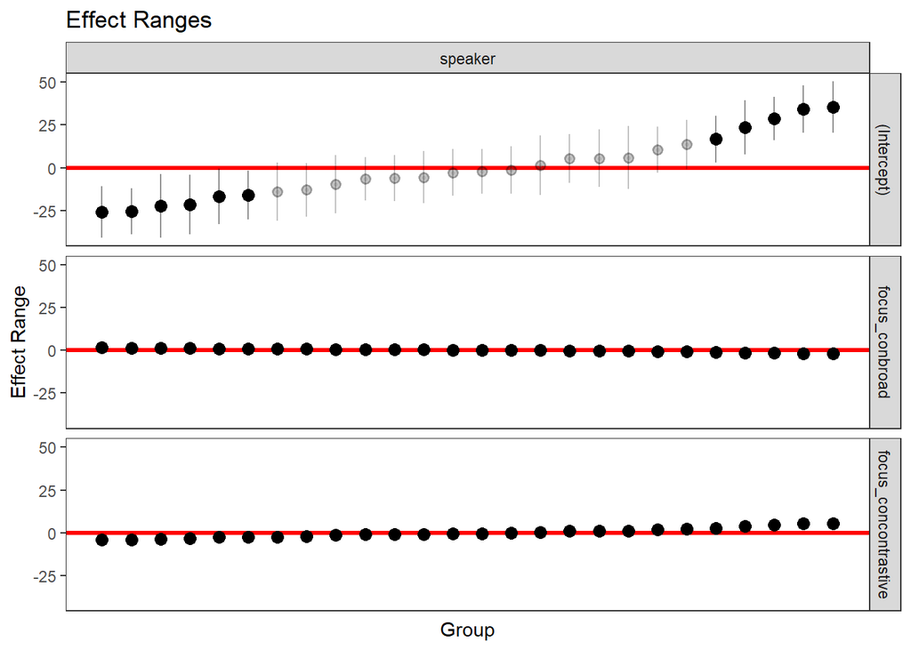

```r
randoms <- REsim(mdl3)
plotREsim(randoms)
```

Plot estimated 95 % interval spans for the intercept of TB velocity

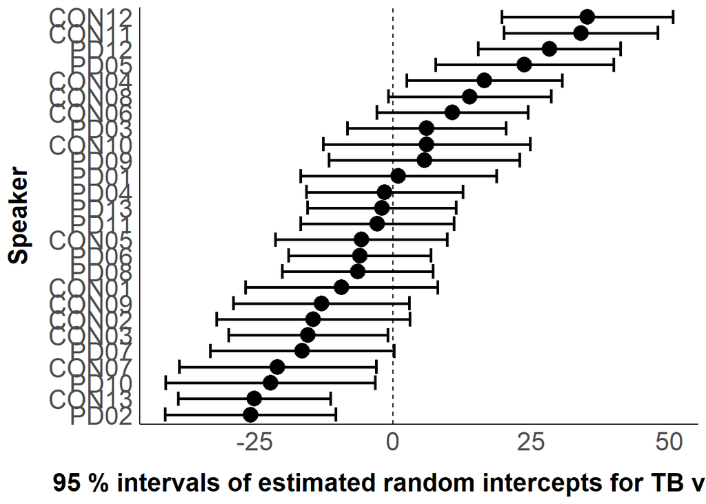

```r
random2 <- subset(randoms, term == "(Intercept)")

random2 %>%
  ggplot(aes(x = mean, xmin = mean-sd-sd, xmax = mean+sd+sd, y = reorder(groupID, mean))) +
  geom_vline(xintercept = 0, linetype = 'dashed') +
  geom_point(size = 5)+
  geom_errorbar(size = 1) +
  theme_classic()+
  xlab('95 % intervals of estimated random intercepts for TB velocity') +
  ylab('Speaker')+
  theme(axis.title.y = element_text(face = 'bold', size = 18, margin = margin(r = 12)))+
  theme(axis.title.x = element_text(face = 'bold', size = 18, margin = margin(t = 12)))+
  theme(strip.text.x = element_text(size=18, face="bold"),
        strip.background = element_blank())+
  theme(axis.text.x = element_text(size = 18),
        axis.text.y = element_text(size = 18)) +
  theme(axis.ticks.x = element_blank(),
        axis.ticks.y = element_blank())+
  theme(legend.position = "top",
        legend.title = element_blank(),
        legend.text = element_text(size = 18))
```

# Movement Profiles

Descriptive stats for reporting values in Table

Subset for production of vowels /a/ and /i/

```r
data_red_i_a <-  filter(data_red, vowel %in% c('i', 'a'))
```

Acceleration phase

```r
ACC_stats <- data_red_i_a %>%
  group_by(med_con) %>%
  summarise(M = round(mean(acc_V1)),
            SD = round(sd(acc_V1)))
ACC_stats
```

```
## # A tibble: 2 x 3
##   med_con     M    SD
##   <chr>   <dbl> <dbl>
## 1 Control    88    32
## 2 med-OFF    99    35
```

```r
ACC_stats2 <- data_red_i_a %>%
  group_by(med_con, focus_con) %>%
  summarise(M = round(mean(acc_V1)),
            SD = round(sd(acc_V1)))
ACC_stats2
```

```
## # A tibble: 6 x 4
## # Groups:   med_con [2]
##   med_con focus_con       M    SD
##   <chr>   <chr>       <dbl> <dbl>
## 1 Control background     84    29
## 2 Control broad          92    35
## 3 Control contrastive    88    31
## 4 med-OFF background     95    34
## 5 med-OFF broad         102    39
## 6 med-OFF contrastive    99    31
```

Deceleration phase

```r
DEC_stats <- data_red_i_a %>%
  group_by(med_con) %>%
  summarise(M = round(mean(dec_V1)),
            SD = round(sd(dec_V1)))
DEC_stats
```

```
## # A tibble: 2 x 3
##   med_con     M    SD
##   <chr>   <dbl> <dbl>
## 1 Control    89    29
## 2 med-OFF   103    35
```

```r
DEC_stats2 <- data_red_i_a %>%
  group_by(med_con, focus_con) %>%
  summarise(M = round(mean(dec_V1)),
            SD = round(sd(dec_V1)))
DEC_stats2
```

```
## # A tibble: 6 x 4
## # Groups:   med_con [2]
##   med_con focus_con       M    SD
##   <chr>   <chr>       <dbl> <dbl>
## 1 Control background     78    21
## 2 Control broad          96    31
## 3 Control contrastive    93    31
## 4 med-OFF background     98    33
## 5 med-OFF broad         102    33
## 6 med-OFF contrastive   109    39
```

Symmetry profile

```r
SYMM_stats <- data_red_i_a %>%
  group_by(med_con) %>%
  summarise(M = round(mean(symmetry_V1),1),
            SD = round(sd(symmetry_V1),1))
SYMM_stats
```

```
## # A tibble: 2 x 3
##   med_con     M    SD
##   <chr>   <dbl> <dbl>
## 1 Control   1.2   0.7
## 2 med-OFF   1.2   0.6
```

```r
SYMM_stats2 <- data_red_i_a %>%
  group_by(med_con, focus_con) %>%
  summarise(M = round(mean(symmetry_V1),1),
            SD = round(sd(symmetry_V1),1))
SYMM_stats2
```

```
## # A tibble: 6 x 4
## # Groups:   med_con [2]
##   med_con focus_con       M    SD
##   <chr>   <chr>       <dbl> <dbl>
## 1 Control background    1.1   0.6
## 2 Control broad         1.2   0.7
## 3 Control contrastive   1.3   0.8
## 4 med-OFF background    1.2   0.6
## 5 med-OFF broad         1.2   0.6
## 6 med-OFF contrastive   1.3   0.7
```

Stiffness

```r
STIFF_stats <- data_red_i_a %>%
  group_by(med_con) %>%
  summarise(M = round(mean(stiffness_V1_abs),1),
            SD = round(sd(stiffness_V1_abs),1))
STIFF_stats
```

```
## # A tibble: 2 x 3
##   med_con     M    SD
##   <chr>   <dbl> <dbl>
## 1 Control  11       5
## 2 med-OFF   9.3     2
```

```r
STIFF_stats2 <- data_red_i_a %>%
  group_by(med_con, focus_con) %>%
  summarise(M = round(mean(stiffness_V1_abs),1),
            SD = round(sd(stiffness_V1_abs),1))
STIFF_stats2
```

```
## # A tibble: 6 x 4
## # Groups:   med_con [2]
##   med_con focus_con       M    SD
##   <chr>   <chr>       <dbl> <dbl>
## 1 Control background   11.4   3.1
## 2 Control broad        10.1   3
## 3 Control contrastive  11.4   7.4
## 4 med-OFF background    9.7   1.9
## 5 med-OFF broad         9.3   2.1
## 6 med-OFF contrastive   9     2.1
```

# Timing pattern

```r
ONS_avgs <- data_red %>%
  group_by(med_con) %>%
  summarise(M = round(mean(onsC1_to_onsV1)),
            SD = round(sd(onsC1_to_onsV1)))
ONS_avgs
```

```
## # A tibble: 2 x 3
##   med_con     M    SD
##   <chr>   <dbl> <dbl>
## 1 Control    20    32
## 2 med-OFF    27    36
```

```r
TARG_avgs <- data_red %>%
  group_by(med_con) %>%
  summarise(M = round(mean(targC1_to_targV1)),
            SD = round(sd(targC1_to_targV1)))
TARG_avgs
```

```
## # A tibble: 2 x 3
##   med_con     M    SD
##   <chr>   <dbl> <dbl>
## 1 Control   104    32
## 2 med-OFF   119    37
```

```r
OnsAlign_avgs <- data_red %>%
  group_by(med_con) %>%
  summarise(M = round(mean(onsV1.syll.dur),2)*100,
            SD = round(sd(onsV1.syll.dur),2)*100)
OnsAlign_avgs
```

```
## # A tibble: 2 x 3
##   med_con     M    SD
##   <chr>   <dbl> <dbl>
## 1 Control   -18    15
## 2 med-OFF   -19    17
```

```r
TargAlign_avgs <- data_red %>%
  group_by(med_con) %>%
  summarise(M = round(mean(targV1.syll.dur),2)*100,
            SD = round(sd(targV1.syll.dur),2)*100)
TargAlign_avgs
```

```
## # A tibble: 2 x 3
##   med_con     M    SD
##   <chr>   <dbl> <dbl>
## 1 Control    70    10
## 2 med-OFF    69    11
```

Statistical analysis for timing patterns

create model for onset to onset interval

```r
mdl4 <- lmer(onsC1_to_onsV1 ~ med_con + focus_con + vowel + cons + age  + (1 + focus_con|speaker), data_red, REML = FALSE)
```

Look at model

```r
summary(mdl4)
```

```
## Linear mixed model fit by maximum likelihood . t-tests use Satterthwaite's
##   method [lmerModLmerTest]
## Formula: onsC1_to_onsV1 ~ med_con + focus_con + vowel + cons + age + (1 +
##     focus_con | speaker)
##    Data: data_red
##
##      AIC      BIC   logLik deviance df.resid
##   7619.1   7698.4  -3792.5   7585.1      767
##
## Scaled residuals:
##     Min      1Q  Median      3Q     Max
## -3.6374 -0.5908 -0.0379  0.5622  9.2152
##
## Random effects:
##  Groups   Name                 Variance Std.Dev. Corr
##  speaker  (Intercept)          140.2849 11.8442
##           focus_conbroad         0.2157  0.4644  -1.00
##           focus_concontrastive   0.1483  0.3850  -1.00  1.00
##  Residual                      880.0457 29.6656
## Number of obs: 784, groups:  speaker, 26
##
## Fixed effects:
##                      Estimate Std. Error       df t value Pr(>|t|)
## (Intercept)           -8.9917    19.2821  27.1838  -0.466    0.645
## med_conmed-OFF         7.1250     5.0030  25.9854   1.424    0.166
## focus_conbroad         1.9085     2.5949 706.6001   0.735    0.462
## focus_concontrastive  -1.1410     2.5963 717.1307  -0.439    0.660
## vowele                18.8982     3.3440 758.0706   5.651 2.25e-08 ***
## voweli                 5.0364     3.3705 758.0625   1.494    0.136
## vowelo                 2.3290     3.3599 758.0764   0.693    0.488
## vowelu                22.0126     3.3594 758.0159   6.553 1.04e-10 ***
## conslab               14.0226     2.1196 758.0297   6.616 6.98e-11 ***
## age                    0.2029     0.3172  26.0350   0.640    0.528
## ---
## Signif. codes:  0 '***' 0.001 '**' 0.01 '*' 0.05 '.' 0.1 ' ' 1
##
## Correlation of Fixed Effects:
##             (Intr) m_-OFF fcs_cnb fcs_cnc vowele voweli vowelo vowelu conslb
## md_cnmd-OFF -0.139
## focus_cnbrd -0.070  0.001
## fcs_cncntrs -0.071  0.000  0.498
## vowele      -0.088 -0.002  0.003   0.007
## voweli      -0.083  0.000  0.000   0.000   0.504
## vowelo      -0.086  0.000  0.010   0.007   0.505  0.502
## vowelu      -0.087 -0.002  0.005   0.005   0.505  0.502  0.503
## conslab     -0.058 -0.002  0.009   0.008   0.002 -0.008 -0.008 -0.004
## age         -0.972  0.009 -0.003  -0.001   0.000 -0.004 -0.002 -0.001  0.003
## optimizer (nloptwrap) convergence code: 0 (OK)
## boundary (singular) fit: see help('isSingular')
```

Extracting fit statistics for reporting in text

```r
tab_model(mdl4)
```

|  | ons C 1 to ons V 1 |  |  |
| --- | --- | --- | --- |
| Predictors | Estimates | CI | p |
| (Intercept) | -8.99 | -46.84 – 28.86 | 0.641 |
| med con [med-OFF] | 7.12 | -2.70 – 16.95 | 0.155 |
| focus con [broad] | 1.91 | -3.19 – 7.00 | 0.462 |
| focus con [contrastive] | -1.14 | -6.24 – 3.96 | 0.660 |
| vowel [e] | 18.90 | 12.33 – 25.46 | **<0.001** |
| vowel [i] | 5.04 | -1.58 – 11.65 | 0.136 |
| vowel [o] | 2.33 | -4.27 – 8.92 | 0.488 |
| vowel [u] | 22.01 | 15.42 – 28.61 | **<0.001** |
| cons [lab] | 14.02 | 9.86 – 18.18 | **<0.001** |
| age | 0.20 | -0.42 – 0.83 | 0.523 |
| Random Effects |  |  |  |
| σ<sup>2</sup> | 880.05 |  |  |
| τ<sub>00</sub> <sub>speaker</sub> | 140.28 |  |  |
| τ<sub>11</sub> <sub>speaker.focus_conbroad</sub> | 0.22 |  |  |
| τ<sub>11</sub> <sub>speaker.focus_concontrastive</sub> | 0.15 |  |  |
| ρ<sub>01</sub> | -1.00 |  |  |
|  | -1.00 |  |  |
| N <sub>speaker</sub> | 26 |  |  |
| Observations | 784 |  |  |
| Marginal R<sup>2</sup> / Conditional R<sup>2</sup> | 0.143 / NA |  |  |

create model for target to target interval

```r
mdl5 <- lmer(targC1_to_targV1 ~ med_con + focus_con + vowel + cons + age  + (1 + focus_con|speaker), data_red, REML = FALSE)
```

Look at model

```r
summary(mdl5)
```

```
## Linear mixed model fit by maximum likelihood . t-tests use Satterthwaite's
##   method [lmerModLmerTest]
## Formula: targC1_to_targV1 ~ med_con + focus_con + vowel + cons + age +
##     (1 + focus_con | speaker)
##    Data: data_red
##
##      AIC      BIC   logLik deviance df.resid
##   7435.0   7514.3  -3700.5   7401.0      767
##
## Scaled residuals:
##     Min      1Q  Median      3Q     Max
## -3.4992 -0.5335  0.0136  0.5406  5.2758
##
## Random effects:
##  Groups   Name                 Variance Std.Dev. Corr
##  speaker  (Intercept)          230.13   15.170
##           focus_conbroad        27.43    5.238   1.00
##           focus_concontrastive  20.74    4.554   1.00 1.00
##  Residual                      671.35   25.910
## Number of obs: 784, groups:  speaker, 26
##
## Fixed effects:
##                      Estimate Std. Error       df t value Pr(>|t|)
## (Intercept)           59.5555    25.8456  28.1746   2.304 0.028789 *
## med_conmed-OFF        16.4419     6.7405  27.5903   2.439 0.021413 *
## focus_conbroad         9.5419     2.4870  74.8221   3.837 0.000258 ***
## focus_concontrastive  12.0518     2.4362  92.4816   4.947 3.36e-06 ***
## vowele               -19.7653     2.9208 757.9145  -6.767 2.63e-11 ***
## voweli               -32.6480     2.9439 757.8981 -11.090  < 2e-16 ***
## vowelo               -15.8847     2.9345 757.8987  -5.413 8.32e-08 ***
## vowelu               -20.4203     2.9341 757.8849  -6.960 7.39e-12 ***
## conslab               -4.3487     1.8513 757.9199  -2.349 0.019076 *
## age                    0.9546     0.4287  27.8512   2.227 0.034213 *
## ---
## Signif. codes:  0 '***' 0.001 '**' 0.01 '*' 0.05 '.' 0.1 ' ' 1
##
## Correlation of Fixed Effects:
##             (Intr) m_-OFF fcs_cnb fcs_cnc vowele voweli vowelo vowelu conslb
## md_cnmd-OFF -0.139
## focus_cnbrd  0.009  0.001
## fcs_cncntrs  0.003  0.001  0.573
## vowele      -0.057 -0.005  0.002   0.007
## voweli      -0.053  0.000  0.000   0.000   0.504
## vowelo      -0.054 -0.002  0.009   0.007   0.505  0.502
## vowelu      -0.055 -0.003  0.004   0.005   0.505  0.502  0.503
## conslab     -0.042 -0.003  0.008   0.007   0.002 -0.008 -0.008 -0.004
## age         -0.980  0.009 -0.002  -0.002   0.000 -0.004 -0.003 -0.002  0.007
## optimizer (nloptwrap) convergence code: 0 (OK)
## boundary (singular) fit: see help('isSingular')
```

Extracting fit statistics for reporting in text

```r
tab_model(mdl5)
```

|  | targ C 1 to targ V 1 |  |  |
| --- | --- | --- | --- |
| Predictors | Estimates | CI | p |
| (Intercept) | 59.56 | 8.82 – 110.29 | **0.021** |
| med con [med-OFF] | 16.44 | 3.21 – 29.67 | **0.015** |
| focus con [broad] | 9.54 | 4.66 – 14.42 | **<0.001** |
| focus con [contrastive] | 12.05 | 7.27 – 16.83 | **<0.001** |
| vowel [e] | -19.77 | -25.50 – -14.03 | **<0.001** |
| vowel [i] | -32.65 | -38.43 – -26.87 | **<0.001** |
| vowel [o] | -15.88 | -21.65 – -10.12 | **<0.001** |
| vowel [u] | -20.42 | -26.18 – -14.66 | **<0.001** |
| cons [lab] | -4.35 | -7.98 – -0.71 | **0.019** |
| age | 0.95 | 0.11 – 1.80 | **0.026** |
| Random Effects |  |  |  |
| σ<sup>2</sup> | 671.35 |  |  |
| τ<sub>00</sub> <sub>speaker</sub> | 230.13 |  |  |
| τ<sub>11</sub> <sub>speaker.focus_conbroad</sub> | 27.43 |  |  |
| τ<sub>11</sub> <sub>speaker.focus_concontrastive</sub> | 20.74 |  |  |
| ρ<sub>01</sub> | 1.00 |  |  |
|  | 1.00 |  |  |
| N <sub>speaker</sub> | 26 |  |  |
| Observations | 784 |  |  |
| Marginal R<sup>2</sup> / Conditional R<sup>2</sup> | 0.282 / NA |  |  |

create model for onset alignment

```r
mdl6 <- lmer(onsV1.syll.dur ~ med_con + focus_con + vowel + cons + age  + (1 + focus_con|speaker), data_red, REML = FALSE)
```

Look at model

```r
summary(mdl6)
```

```
## Linear mixed model fit by maximum likelihood . t-tests use Satterthwaite's
##   method [lmerModLmerTest]
## Formula: onsV1.syll.dur ~ med_con + focus_con + vowel + cons + age + (1 +
##     focus_con | speaker)
##    Data: data_red
##
##      AIC      BIC   logLik deviance df.resid
##   -816.3   -737.0    425.2   -850.3      767
##
## Scaled residuals:
##     Min      1Q  Median      3Q     Max
## -6.6037 -0.5973  0.0445  0.6849  3.2046
##
## Random effects:
##  Groups   Name                 Variance  Std.Dev. Corr
##  speaker  (Intercept)          3.879e-03 0.062283
##           focus_conbroad       1.738e-06 0.001318 -1.00
##           focus_concontrastive 5.408e-05 0.007354 -1.00  1.00
##  Residual                      1.858e-02 0.136301
## Number of obs: 784, groups:  speaker, 26
##
## Fixed effects:
##                        Estimate Std. Error         df t value Pr(>|t|)
## (Intercept)           -0.326917   0.096527  27.158369  -3.387  0.00217 **
## med_conmed-OFF        -0.014811   0.025078  26.098479  -0.591  0.55987
## focus_conbroad         0.022527   0.011918 737.018194   1.890  0.05914 .
## focus_concontrastive   0.021201   0.012011 368.336207   1.765  0.07838 .
## vowele                 0.047614   0.015365 757.947626   3.099  0.00201 **
## voweli                -0.028813   0.015486 757.940449  -1.861  0.06320 .
## vowelo                -0.009963   0.015438 757.953974  -0.645  0.51888
## vowelu                 0.066759   0.015435 757.896346   4.325 1.73e-05 ***
## conslab                0.079877   0.009739 757.910415   8.202 1.01e-15 ***
## age                    0.001296   0.001590  26.125843   0.815  0.42252
## ---
## Signif. codes:  0 '***' 0.001 '**' 0.01 '*' 0.05 '.' 0.1 ' ' 1
##
## Correlation of Fixed Effects:
##             (Intr) m_-OFF fcs_cnb fcs_cnc vowele voweli vowelo vowelu conslb
## md_cnmd-OFF -0.139
## focus_cnbrd -0.063  0.001
## fcs_cncntrs -0.077  0.000  0.497
## vowele      -0.081 -0.002  0.003   0.007
## voweli      -0.077  0.000  0.000   0.000   0.504
## vowelo      -0.079  0.000  0.010   0.007   0.505  0.502
## vowelu      -0.080 -0.001  0.005   0.005   0.505  0.502  0.503
## conslab     -0.052 -0.001  0.009   0.008   0.002 -0.008 -0.008 -0.004
## age         -0.973  0.010 -0.002  -0.001   0.000 -0.003 -0.001 -0.001  0.002
## optimizer (nloptwrap) convergence code: 0 (OK)
## boundary (singular) fit: see help('isSingular')
```

Extracting fit statistics for reporting in text

```r
tab_model(mdl6)
```

|  | ons V 1.syll dur |  |  |
| --- | --- | --- | --- |
| Predictors | Estimates | CI | p |
| (Intercept) | -0.33 | -0.52 – -0.14 | **0.001** |
| med con [med-OFF] | -0.01 | -0.06 – 0.03 | 0.555 |
| focus con [broad] | 0.02 | -0.00 – 0.05 | 0.059 |
| focus con [contrastive] | 0.02 | -0.00 – 0.04 | 0.078 |
| vowel [e] | 0.05 | 0.02 – 0.08 | **0.002** |
| vowel [i] | -0.03 | -0.06 – 0.00 | 0.063 |
| vowel [o] | -0.01 | -0.04 – 0.02 | 0.519 |
| vowel [u] | 0.07 | 0.04 – 0.10 | **<0.001** |
| cons [lab] | 0.08 | 0.06 – 0.10 | **<0.001** |
| age | 0.00 | -0.00 – 0.00 | 0.415 |
| Random Effects |  |  |  |
| σ<sup>2</sup> | 0.02 |  |  |
| τ<sub>00</sub> <sub>speaker</sub> | 0.00 |  |  |
| τ<sub>11</sub> <sub>speaker.focus_conbroad</sub> | 0.00 |  |  |
| τ<sub>11</sub> <sub>speaker.focus_concontrastive</sub> | 0.00 |  |  |
| ρ<sub>01</sub> | -1.00 |  |  |
|  | -1.00 |  |  |
| N <sub>speaker</sub> | 26 |  |  |
| Observations | 784 |  |  |
| Marginal R<sup>2</sup> / Conditional R<sup>2</sup> | 0.144 / NA |  |  |

create model for target alignment

```r
mdl7 <- lmer(targV1.syll.dur ~ med_con + focus_con + vowel + cons + age + (1 + focus_con|speaker), data_red, REML = FALSE)
```

Look at model

```r
summary(mdl7)
```

```
## Linear mixed model fit by maximum likelihood . t-tests use Satterthwaite's
##   method [lmerModLmerTest]
## Formula: targV1.syll.dur ~ med_con + focus_con + vowel + cons + age +
##     (1 + focus_con | speaker)
##    Data: data_red
##
##      AIC      BIC   logLik deviance df.resid
##  -1388.5  -1309.2    711.3  -1422.5      767
##
## Scaled residuals:
##     Min      1Q  Median      3Q     Max
## -3.6898 -0.5303  0.0596  0.5794  3.1242
##
## Random effects:
##  Groups   Name                 Variance  Std.Dev.  Corr
##  speaker  (Intercept)          5.864e-04 0.0242156
##           focus_conbroad       7.695e-07 0.0008772 -1.00
##           focus_concontrastive 6.105e-07 0.0007813  1.00 -1.00
##  Residual                      9.207e-03 0.0959515
## Number of obs: 784, groups:  speaker, 26
##
## Fixed effects:
##                        Estimate Std. Error         df t value Pr(>|t|)
## (Intercept)           6.067e-01  4.553e-02  2.824e+01  13.326 1.05e-13 ***
## med_conmed-OFF       -1.001e-02  1.170e-02  2.596e+01  -0.856 0.400050
## focus_conbroad       -4.034e-03  8.389e-03  7.376e+02  -0.481 0.630742
## focus_concontrastive -2.855e-03  8.395e-03  7.421e+02  -0.340 0.733868
## vowele                3.967e-02  1.082e-02  7.581e+02   3.668 0.000261 ***
## voweli                4.926e-02  1.090e-02  7.581e+02   4.519 7.21e-06 ***
## vowelo               -1.693e-02  1.087e-02  7.581e+02  -1.558 0.119612
## vowelu                5.223e-02  1.087e-02  7.580e+02   4.807 1.85e-06 ***
## conslab              -2.864e-02  6.855e-03  7.580e+02  -4.177 3.30e-05 ***
## age                   1.403e-03  7.423e-04  2.608e+01   1.891 0.069835 .
## ---
## Signif. codes:  0 '***' 0.001 '**' 0.01 '*' 0.05 '.' 0.1 ' ' 1
##
## Correlation of Fixed Effects:
##             (Intr) m_-OFF fcs_cnb fcs_cnc vowele voweli vowelo vowelu conslb
## md_cnmd-OFF -0.137
## focus_cnbrd -0.092  0.002
## fcs_cncntrs -0.090  0.001  0.497
## vowele      -0.121 -0.004  0.003   0.007
## voweli      -0.114  0.000  0.000   0.000   0.504
## vowelo      -0.118  0.000  0.010   0.007   0.505  0.502
## vowelu      -0.119 -0.002  0.005   0.005   0.506  0.502  0.503
## conslab     -0.079 -0.003  0.009   0.008   0.002 -0.008 -0.008 -0.004
## age         -0.963  0.009 -0.004  -0.001   0.000 -0.005 -0.003 -0.001  0.004
## optimizer (nloptwrap) convergence code: 0 (OK)
## boundary (singular) fit: see help('isSingular')
```

Extracting fit statistics for reporting in text

```r
tab_model(mdl7)
```

|  | targ V 1.syll dur |  |  |
| --- | --- | --- | --- |
| Predictors | Estimates | CI | p |
| (Intercept) | 0.61 | 0.52 – 0.70 | **<0.001** |
| med con [med-OFF] | -0.01 | -0.03 – 0.01 | 0.392 |
| focus con [broad] | -0.00 | -0.02 – 0.01 | 0.631 |
| focus con [contrastive] | -0.00 | -0.02 – 0.01 | 0.734 |
| vowel [e] | 0.04 | 0.02 – 0.06 | **<0.001** |
| vowel [i] | 0.05 | 0.03 – 0.07 | **<0.001** |
| vowel [o] | -0.02 | -0.04 – 0.00 | 0.120 |
| vowel [u] | 0.05 | 0.03 – 0.07 | **<0.001** |
| cons [lab] | -0.03 | -0.04 – -0.02 | **<0.001** |
| age | 0.00 | -0.00 – 0.00 | 0.059 |
| Random Effects |  |  |  |
| σ<sup>2</sup> | 0.01 |  |  |
| τ<sub>00</sub> <sub>speaker</sub> | 0.00 |  |  |
| τ<sub>11</sub> <sub>speaker.focus_conbroad</sub> | 0.00 |  |  |
| τ<sub>11</sub> <sub>speaker.focus_concontrastive</sub> | 0.00 |  |  |
| ρ<sub>01</sub> | -1.00 |  |  |
|  | 1.00 |  |  |
| N <sub>speaker</sub> | 26 |  |  |
| Observations | 784 |  |  |
| Marginal R<sup>2</sup> / Conditional R<sup>2</sup> | 0.111 / NA |  |  |